# problemSet3

## Break out the Histogram Diamond Prices by Cut

I could use a grid to do this, but I’m going to start by trying a facet wrap.

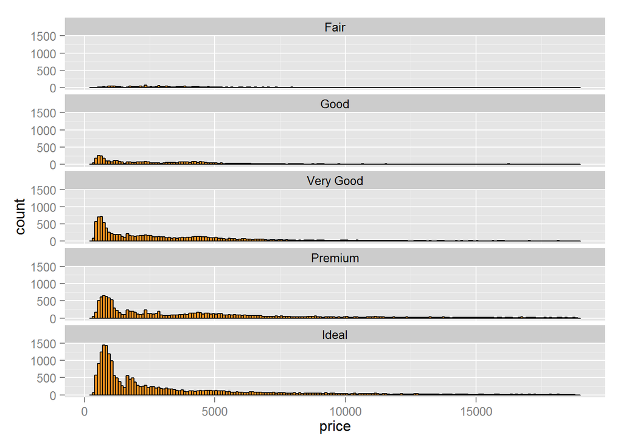

```r
ggplot(aes(x = price), data = diamonds) +
  geom_histogram(binwidth = 100,  color = 'black',fill = '#F79420') +
  facet_wrap(~cut,ncol = 1)
```

Data is long-tailed, transforming onto log scale

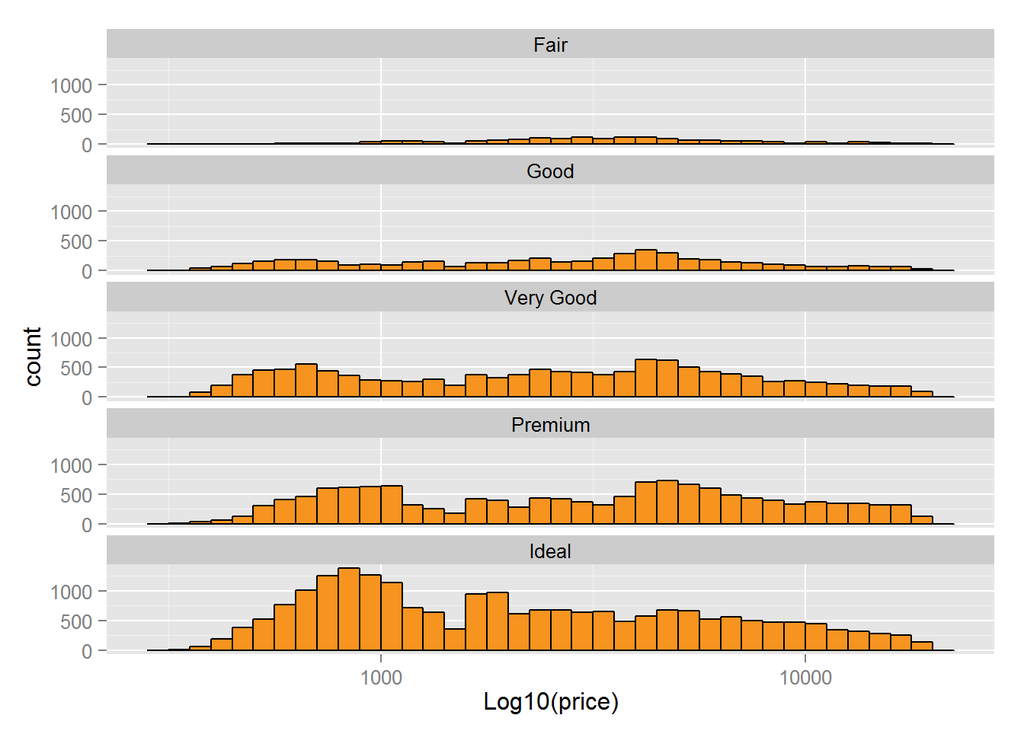

```r
ggplot(aes(x = price), data = diamonds) +
  geom_histogram(binwidth = .05,  color = 'black',fill = '#F79420') +
  scale_x_log10()+
  xlab('Log10(price)') +
  facet_wrap(~cut,ncol = 1)
```

The distributions have similiar shapes, the most different is the fair cut.

## Basic Price Information by Cut

```r
by(diamonds$price,diamonds$cut,max)
```

```
## diamonds$cut: Fair
## [1] 18574
## --------------------------------------------------------
## diamonds$cut: Good
## [1] 18788
## --------------------------------------------------------
## diamonds$cut: Very Good
## [1] 18818
## --------------------------------------------------------
## diamonds$cut: Premium
## [1] 18823
## --------------------------------------------------------
## diamonds$cut: Ideal
## [1] 18806
```

```r
by(diamonds$price,diamonds$cut,min)
```

```
## diamonds$cut: Fair
## [1] 337
## --------------------------------------------------------
## diamonds$cut: Good
## [1] 327
## --------------------------------------------------------
## diamonds$cut: Very Good
## [1] 336
## --------------------------------------------------------
## diamonds$cut: Premium
## [1] 326
## --------------------------------------------------------
## diamonds$cut: Ideal
## [1] 326
```

```r
by(diamonds$price,diamonds$cut,median)
```

```
## diamonds$cut: Fair
## [1] 3282
## --------------------------------------------------------
## diamonds$cut: Good
## [1] 3050.5
## --------------------------------------------------------
## diamonds$cut: Very Good
## [1] 2648
## --------------------------------------------------------
## diamonds$cut: Premium
## [1] 3185
## --------------------------------------------------------
## diamonds$cut: Ideal
## [1] 1810
```

## Free Scales

[output not shown]

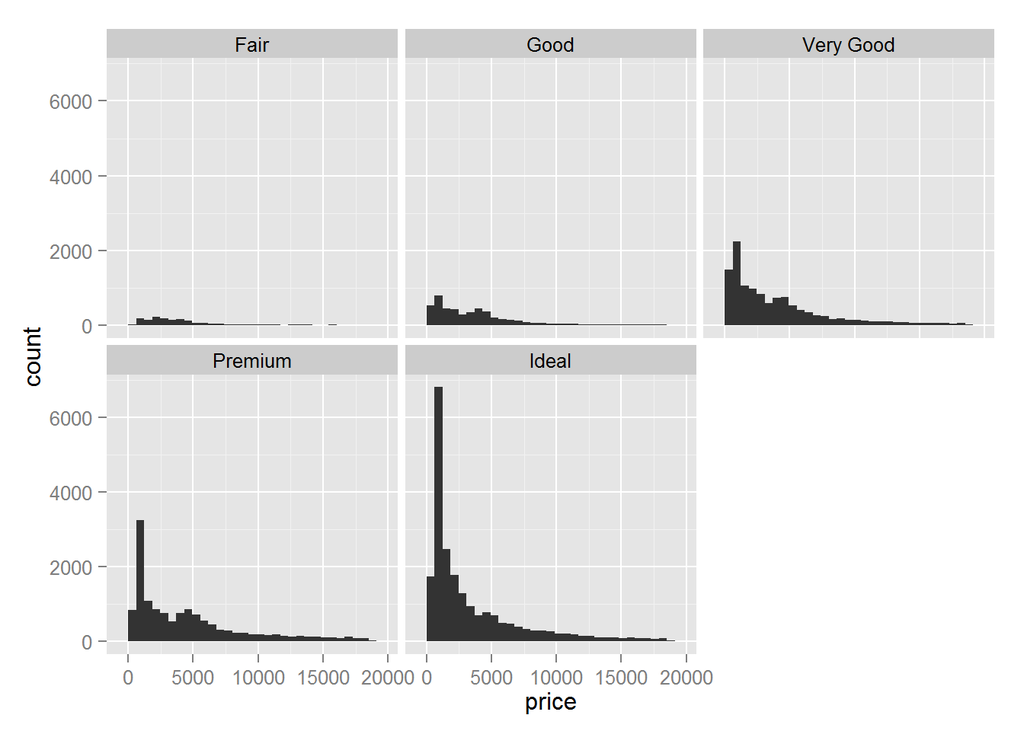

```r
# In the two last exercises, we looked at
# the distribution for diamonds by cut.

# Run the code below in R Studio to generate
# the histogram as a reminder.

# ===============================================================

qplot(x = price, data = diamonds) + facet_wrap(~cut)
```

```r
# ===============================================================

# In the last exercise, we looked at the summary statistics
# for diamond price by cut. If we look at the output table, the
# the median and quartiles are reasonably close to each other.

# diamonds$cut: Fair
#    Min. 1st Qu.  Median    Mean 3rd Qu.    Max.
#     337    2050    3282    4359    5206   18570
# ------------------------------------------------------------------------
# diamonds$cut: Good
#    Min. 1st Qu.  Median    Mean 3rd Qu.    Max.
#     327    1145    3050    3929    5028   18790
# ------------------------------------------------------------------------
# diamonds$cut: Very Good
#    Min. 1st Qu.  Median    Mean 3rd Qu.    Max.
#     336     912    2648    3982    5373   18820
# ------------------------------------------------------------------------
# diamonds$cut: Premium
#    Min. 1st Qu.  Median    Mean 3rd Qu.    Max.
#     326    1046    3185    4584    6296   18820
# ------------------------------------------------------------------------
# diamonds$cut: Ideal
#    Min. 1st Qu.  Median    Mean 3rd Qu.    Max.
#     326     878    1810    3458    4678   18810

# This means the distributions should be somewhat similar,
# but the histograms we created don't show that.

# The 'Fair' and 'Good' diamonds appear to have
# different distributions compared to the better
# cut diamonds. They seem somewhat uniform
# on the left with long tails on the right.

# Let's look in to this more.

# Look up the documentation for facet_wrap in R Studio.
# Then, scroll back up and add a parameter to facet_wrap so that
# the y-axis in the histograms is not fixed. You want the y-axis to
# be different for each histogram.

# If you want a hint, check out the Instructor Notes.
```

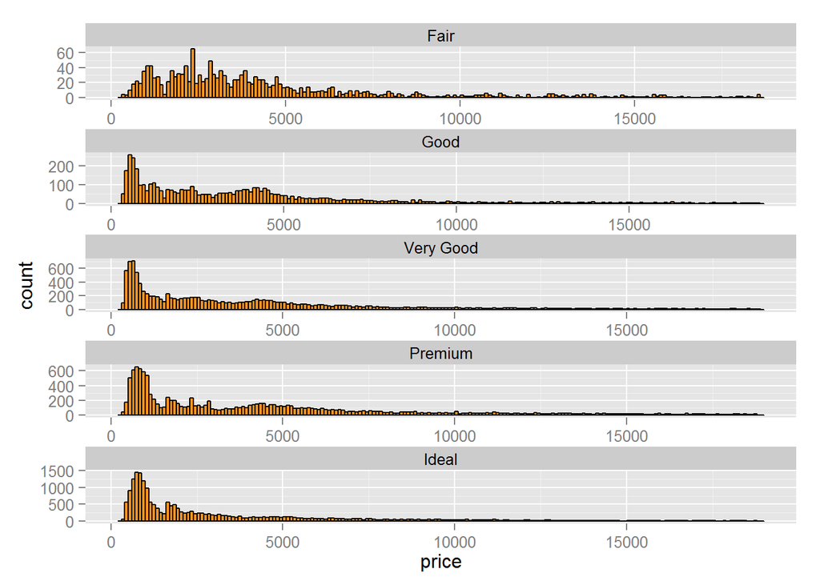

```r
ggplot(aes(x = price), data = diamonds) +
  geom_histogram(binwidth = 100,  color = 'black',fill = '#F79420') +
  facet_wrap(~cut,ncol = 1, scales = 'free')
```

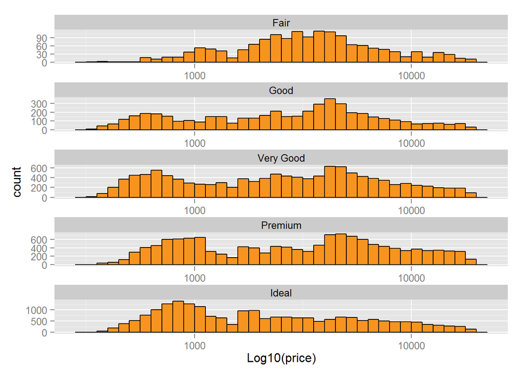

```r
ggplot(aes(x = price), data = diamonds) +
  geom_histogram(binwidth = .05,  color = 'black',fill = '#F79420') +
  scale_x_log10()+
  xlab('Log10(price)') +
  facet_wrap(~cut,ncol = 1, scales = 'free')
```

Now what we visualize is mathing up with what we know about the data (similiar distributions)

## Histogram of Price per Carat Faceted by Cut

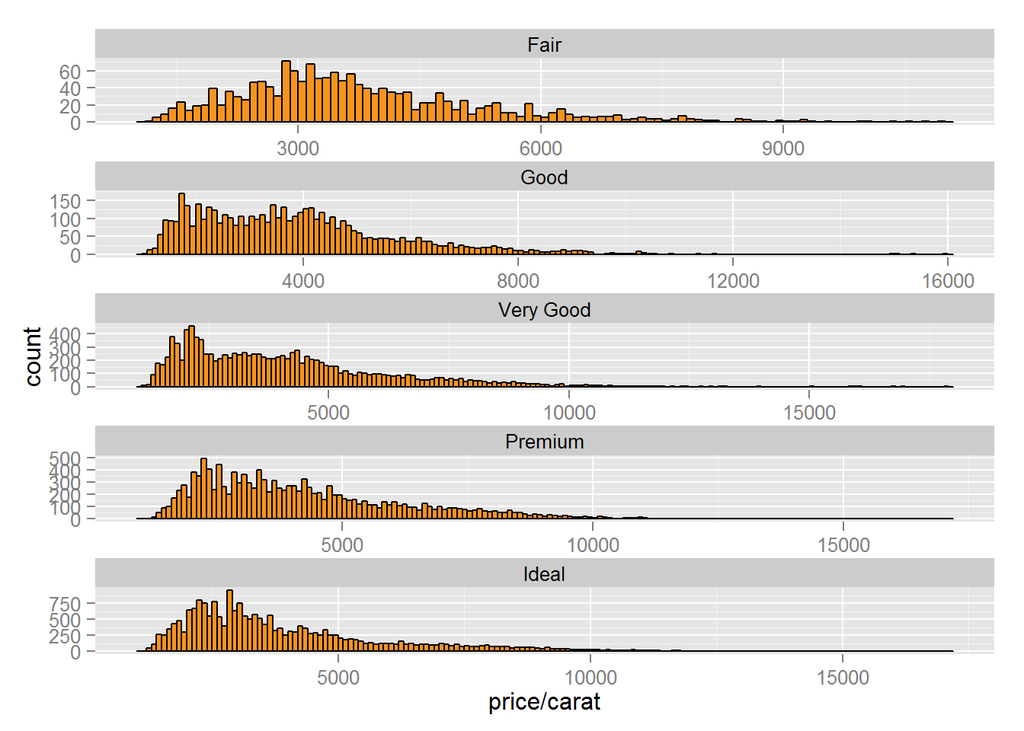

```r
ggplot(aes(x = price/carat), data = diamonds) +
  geom_histogram(binwidth = 100,  color = 'black',fill = '#F79420') +
  facet_wrap(~cut,ncol = 1, scales = 'free')
```

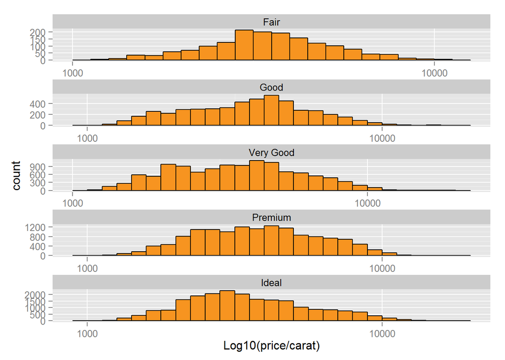

```r
ggplot(aes(x = price/carat), data = diamonds) +
  geom_histogram(binwidth = .05,  color = 'black',fill = '#F79420') +
  scale_x_log10()+
  xlab('Log10(price/carat)') +
  facet_wrap(~cut,ncol = 1, scales = 'free')
```

## Investigate the price of diamonds using box plots,numerical summaries, and one of the following categorical variables: cut, clarity, or color.

```r
library(gridExtra)
```

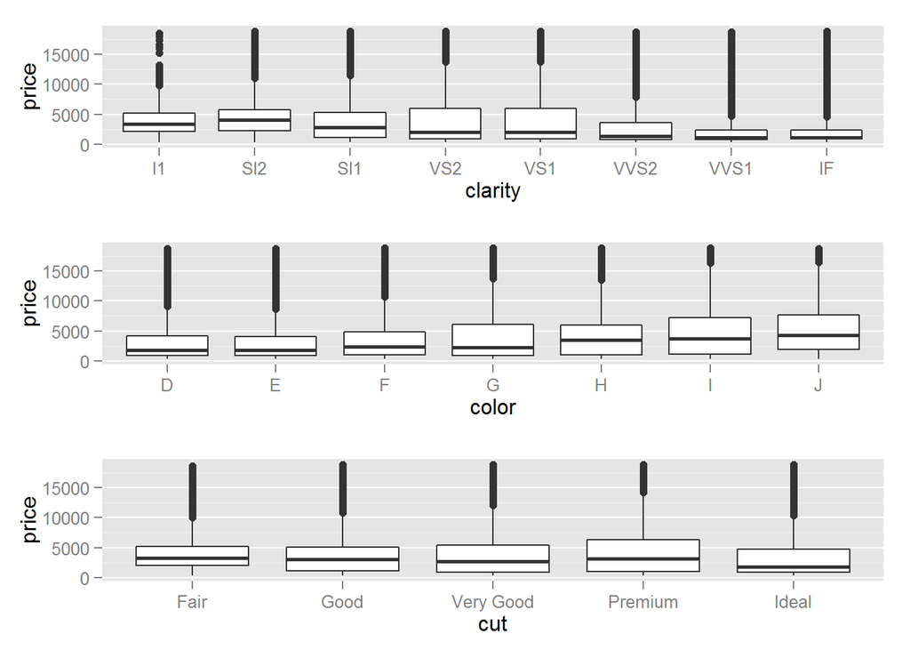

```r
clarity = qplot(x = clarity, y = price,data = diamonds,geom = 'boxplot') +
  coord_cartesian()


color = qplot(x = color, y = price,data = diamonds,geom = 'boxplot') +
  coord_cartesian()

cut = qplot(x = cut, y = price,data = diamonds,geom = 'boxplot') +
  coord_cartesian()

grid.arrange(clarity, color, cut, ncol = 1)
```

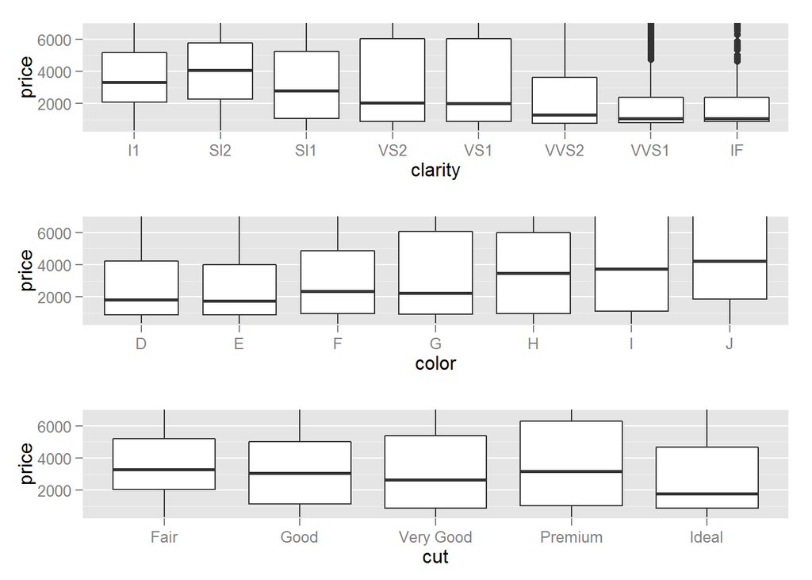

```r
clarity = qplot(x = clarity, y = price,data = diamonds,geom = 'boxplot') +
  coord_cartesian(ylim = c(250,7000))


color = qplot(x = color, y = price,data = diamonds,geom = 'boxplot') +
  coord_cartesian(ylim = c(250,7000))

cut = qplot(x = cut, y = price,data = diamonds,geom = 'boxplot') +
  coord_cartesian(ylim = c(250,7000))

grid.arrange(clarity, color, cut, ncol = 1)
```

```r
by(diamonds$price,diamonds$cut, median)
```

```
## diamonds$cut: Fair
## [1] 3282
## --------------------------------------------------------
## diamonds$cut: Good
## [1] 3050.5
## --------------------------------------------------------
## diamonds$cut: Very Good
## [1] 2648
## --------------------------------------------------------
## diamonds$cut: Premium
## [1] 3185
## --------------------------------------------------------
## diamonds$cut: Ideal
## [1] 1810
```

```r
by(diamonds$price,diamonds$cut, max)
```

```
## diamonds$cut: Fair
## [1] 18574
## --------------------------------------------------------
## diamonds$cut: Good
## [1] 18788
## --------------------------------------------------------
## diamonds$cut: Very Good
## [1] 18818
## --------------------------------------------------------
## diamonds$cut: Premium
## [1] 18823
## --------------------------------------------------------
## diamonds$cut: Ideal
## [1] 18806
```

```r
by(diamonds$price,diamonds$cut, min)
```

```
## diamonds$cut: Fair
## [1] 337
## --------------------------------------------------------
## diamonds$cut: Good
## [1] 327
## --------------------------------------------------------
## diamonds$cut: Very Good
## [1] 336
## --------------------------------------------------------
## diamonds$cut: Premium
## [1] 326
## --------------------------------------------------------
## diamonds$cut: Ideal
## [1] 326
```

```r
by(diamonds$price,diamonds$cut, mean)
```

```
## diamonds$cut: Fair
## [1] 4358.758
## --------------------------------------------------------
## diamonds$cut: Good
## [1] 3928.864
## --------------------------------------------------------
## diamonds$cut: Very Good
## [1] 3981.76
## --------------------------------------------------------
## diamonds$cut: Premium
## [1] 4584.258
## --------------------------------------------------------
## diamonds$cut: Ideal
## [1] 3457.542
```

```r
by(diamonds$price,diamonds$cut, median) - by(diamonds$price,diamonds$cut, mean)
```

```
## diamonds$cut: Fair
## [1] -1076.758
## --------------------------------------------------------
## diamonds$cut: Good
## [1] -878.3645
## --------------------------------------------------------
## diamonds$cut: Very Good
## [1] -1333.76
## --------------------------------------------------------
## diamonds$cut: Premium
## [1] -1399.258
## --------------------------------------------------------
## diamonds$cut: Ideal
## [1] -1647.542
```

I just find the trends in the medians interesting. For cut, the medians are similiar except for ideal. For color they tend to go up in a linear fashion to J (worst color rating), and for clarity they tend to go down. What I see is that there are a variety of factors tha affect price. I think to really understand this we have to plot and view the data in other ways.

## Numerical Analysis

-What is the price range for the middle 50% of diamonds with color D?

```r
by(diamonds$price,(diamonds$color == 'D'), summary)
```

```
## (diamonds$color == "D"): FALSE
##    Min. 1st Qu.  Median    Mean 3rd Qu.    Max.
##     326     958    2503    4042    5527   18820
## --------------------------------------------------------
## (diamonds$color == "D"): TRUE
##    Min. 1st Qu.  Median    Mean 3rd Qu.    Max.
##     357     911    1838    3170    4214   18690
```

-What is the price range for the middle 50% of diamonds with color J?

```r
by(diamonds$price,(diamonds$color == 'J'), summary)
```

```
## (diamonds$color == "J"): FALSE
##    Min. 1st Qu.  Median    Mean 3rd Qu.    Max.
##     326     939    2351    3856    5219   18820
## --------------------------------------------------------
## (diamonds$color == "J"): TRUE
##    Min. 1st Qu.  Median    Mean 3rd Qu.    Max.
##     335    1860    4234    5324    7695   18710
```

-What is the IQR for diamonds wit the best color?

```r
by(diamonds$price,(diamonds$color == 'D'), IQR)
```

```
## (diamonds$color == "D"): FALSE
## [1] 4569
## --------------------------------------------------------
## (diamonds$color == "D"): TRUE
## [1] 3302.5
```

-What is the IQR for diamonds with the worst color?

```r
by(diamonds$price,(diamonds$color == 'J'), IQR)
```

```
## (diamonds$color == "J"): FALSE
## [1] 4280
## --------------------------------------------------------
## (diamonds$color == "J"): TRUE
## [1] 5834.5
```

Instructor Notes

You can use the function IQR() to find the interquartile range. Pass it a subset of the diamonds data frame.

For example… IQR(subset(diamonds, price <1000)$price) Remember subset returns a data frame so we need to use$price on the end to access that variable.

## Investigate the price per carat of diamonds across the different colors of diamonds using boxplots.

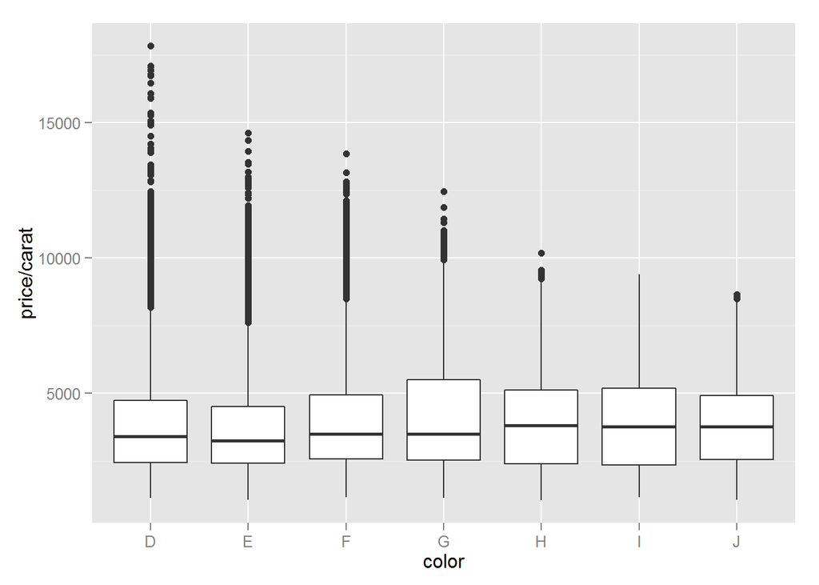

```r
qplot(x = color, y = price/carat,data = diamonds,geom = 'boxplot') +
  coord_cartesian()
```

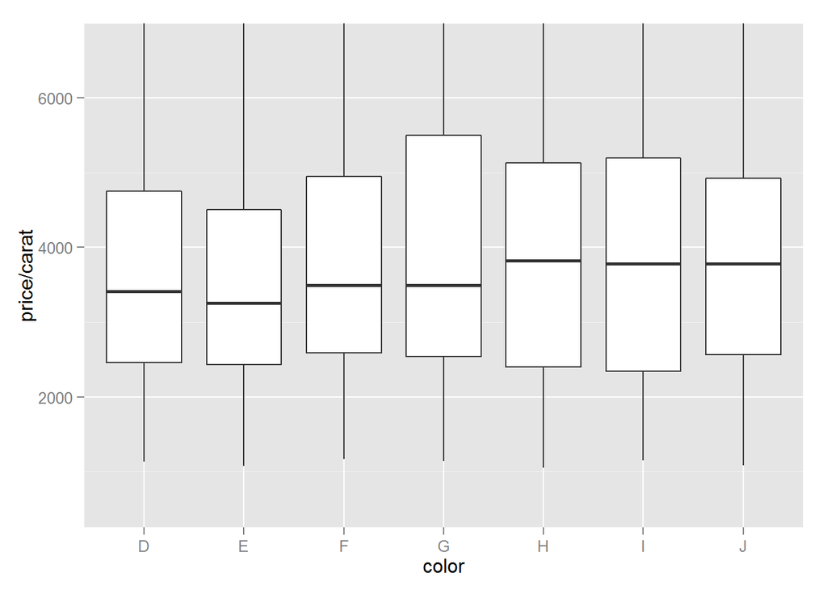

```r
qplot(x = color, y = price/carat,data = diamonds,geom = 'boxplot') +
  coord_cartesian(ylim = c(250,7000))
```

## Investigate weight of diamonds (carat) with a frequency polygon

**how does binwidth affect the polygon?**

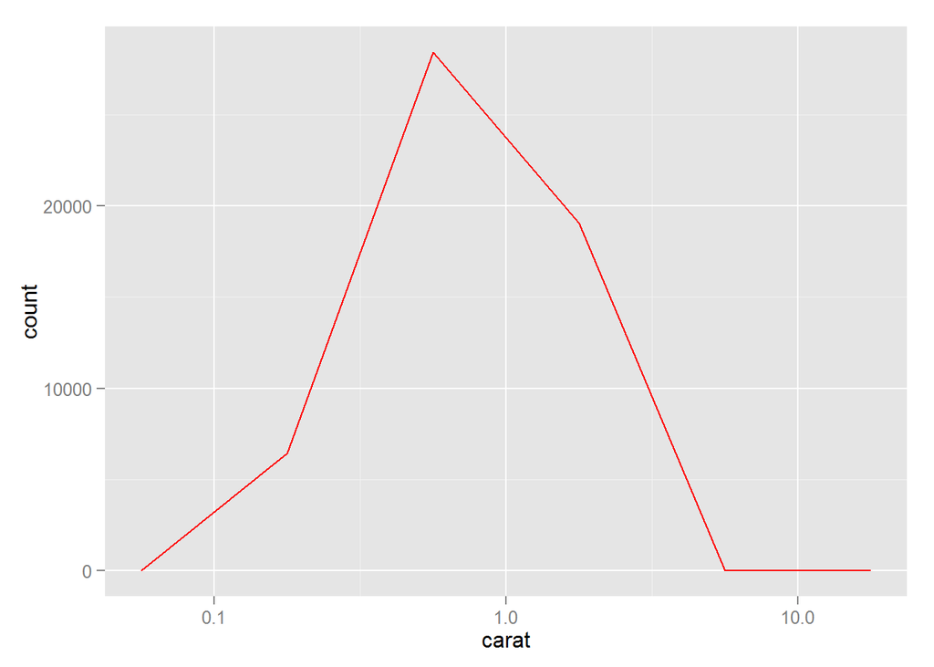

```r
ggplot(aes(x = carat), data = diamonds) +
  geom_freqpoly(binwidth = .5,color = 'red')+
  scale_x_log10()
```

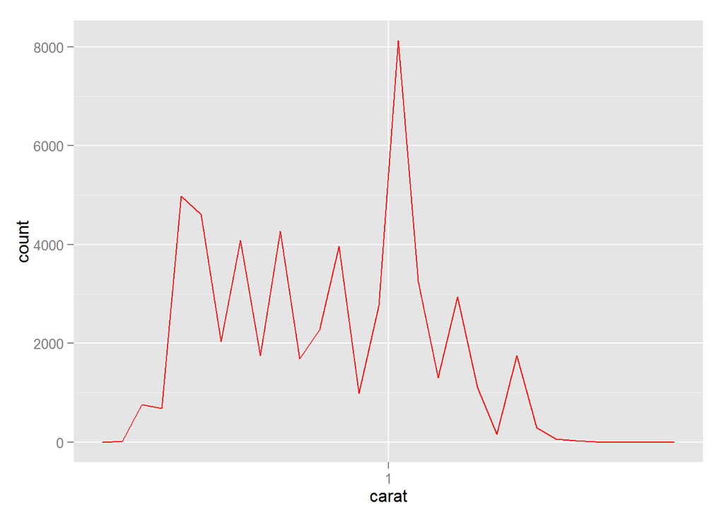

```r
ggplot(aes(x = carat), data = diamonds) +
  geom_freqpoly(binwidth = .05,color = 'red')+
  scale_x_log10()
```

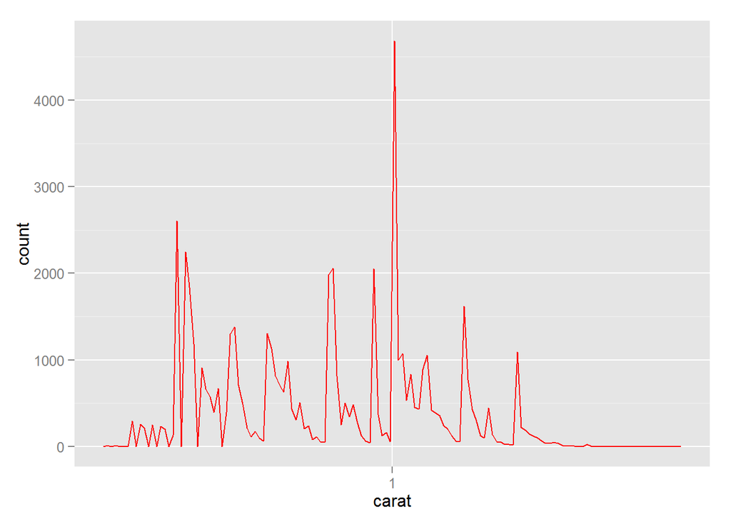

```r
ggplot(aes(x = carat), data = diamonds) +
  geom_freqpoly(binwidth = .01,color = 'red')+
  scale_x_log10()
```

**What carat size(s) has a count > 2000?**

```r
#I have been using subset to do this, but instead used brackets as a select
#statement here, much like I do in PANDAS.
table(diamonds$carat)[table(diamonds$carat)>2000]
```

```
##
##  0.3 0.31 1.01
## 2604 2249 2242
```